# Korygowanie danych

dr Magdalena Guzowska

Dane najczęściej wymagają wstępnego przetwarzania. Często wymagają ingerencji wynikającej z braku niektórych danych, albo, ze wzgledu na swój rozkład, - transformacji.

## Dane brakujące

W R brakujące obserwacje oznaczane są `NA` a funkcja `is.na` sprawdza, czy takie dane wystepują. Wynikiem jej działania jest obiekt R (wektor, macierz, ramka danych) wypełniona wartościami `TRUE` lub `FALSE`.

### Usuwanie obserwacji zawierających brakujące dane

Najprostszą metodą jest usunięcie całego wiersza zawierającego brakujące dane `complete.cases` z ramki danych, lub przy użyciu `na.omit` w przypadku wektorów. Nie jest to metoda polecana, bo może doprowadzić do usunięcie kilkudziesięciu % danych, w kTórych brakowało po 1 obserwacji.

```r
library(missForest)
data("iris")
iris.mis <- prodNA(iris, noNA = 0.1)
summary(iris.mis)
```

```
  Sepal.Length    Sepal.Width     Petal.Length    Petal.Width
 Min.   :4.300   Min.   :2.000   Min.   :1.200   Min.   :0.100
 1st Qu.:5.100   1st Qu.:2.800   1st Qu.:1.600   1st Qu.:0.300
 Median :5.800   Median :3.000   Median :4.400   Median :1.300
 Mean   :5.852   Mean   :3.059   Mean   :3.809   Mean   :1.176
 3rd Qu.:6.400   3rd Qu.:3.400   3rd Qu.:5.100   3rd Qu.:1.800
 Max.   :7.900   Max.   :4.400   Max.   :6.900   Max.   :2.500
 NA's   :16      NA's   :15      NA's   :11      NA's   :17
       Species
 setosa    :47
 versicolor:43
 virginica :44
 NA's      :16
```

```r
# Wybór tylko kompletnych wierszy
indeksKompletnych <- complete.cases(iris.mis)
dim(iris.mis[indeksKompletnych,])
```

```
[1] 87  5
```

```r
# usuwamy dane zawierające brakujące dane w 2 kolumnie (Sepal.Width)
summary(iris.mis[,2])
```

```
   Min. 1st Qu.  Median    Mean 3rd Qu.    Max.    NA's
  2.000   2.800   3.000   3.059   3.400   4.400      15
```

```r
summary(na.omit(iris.mis[,2]))
```

```
   Min. 1st Qu.  Median    Mean 3rd Qu.    Max.
  2.000   2.800   3.000   3.059   3.400   4.400
```

### Uzupełnianie brakujących danych

Zalecanym postępowaniem jest sztuczne wprowadzanie danych w miejsce danych brakujących. Możlna dokonać tego na 2 sposoby:

1. Wstawiając wartości charakterystyczne dla danej zmiennej - średniej, mediany lub mody. Możliwe jest też dopasowanie modelu regresji i wygenerowanie danych na jego podstawie.

```r
library(mice)
library(Hmisc)
# Wektor z brakującymi obserwacjami
wektor <- c(1,5,NA,2,8,8,3,NA,10,4)

# wstawianie wartości 2.5
impute(wektor, 2.5)
```

```
    1     2     3     4     5     6     7     8     9    10
  1.0   5.0  2.5*   2.0   8.0   8.0   3.0  2.5*  10.0   4.0
```

```r
# wstawianie watrości średniej
impute(wektor, mean)
```

```
      1       2       3       4       5       6       7       8       9
  1.000   5.000  5.125*   2.000   8.000   8.000   3.000  5.125*  10.000
     10
  4.000
```

```r
# wstawianie wartości losowych
impute(wektor, "random")
```

```
  1   2   3   4   5   6   7   8   9  10
  1   5  5*   2   8   8   3  4*  10   4
```

2. Wygenerowanie wielu replikacji zbioru danych z imputacjami. W kazdej replikacji brakujące dane zastępowane sa przez obserwacje z rozkladu określonego dla danej zmiennej. Wyniki poszczególnych kroków są ze sobą zestawiane.

#### Pakiety R do uzupełniania brakujących danych

Istnieje kilka mozliwości uzupełniania danych brakujacych w R, ale utworzyonych zostało 5 dobrych pakietów do uzupełniania danych. Kazdy z nich wykorzystuje inne algorytmy i ma inne możliwości, więc można dobrać metodykę do specyfiki danych lub własnych preferencji. Za najlepszy uznawany jest jednak `Himsc`, a następne w kolejności są `missForest` i `MICE`. `Himsc` automatycznie rozpoznaje typ zmiennych i używa techniki bootstrap i dopasowywania przewidywanych średnich do uzupełnienia brakujących danych. Nie ma potrzeby oddzielania danych kategorycznych, czego wymaga `MICE`. `missForest` może być bardziej efektywny niż `Himsc`, pod warunkiem, że ma wystarczająco dużo danych do przeanalizowania.

#### Hmisc

Hmisc jest wielofunkcyjnym pakietem przydatnym do analizowania danych, tworzenia wykresów, wstawiania danych brakujących, tworzenia tabel, dopasowywania modeli (regresje) itd. Posiada 2 bardzo efektywne funkcje służące wstawianiu brakujacych wartości `impute` i `aregImpute`.

`impute` wstawia dane brakujace korzystając z wybranych przez użytkownika funkcji (mean, max, mean). Standardowo jest to mediana. Funkcja `aregImpute` pozwala na korzystanie z regresji, boothstrap i przewidywania średniej.

```r
#install package and load library
library(Hmisc)
library(missForest)

#load data
data("iris")

#seed missing values ( 10% )
iris.mis <- prodNA(iris, noNA = 0.1)
summary(iris.mis)
```

```
  Sepal.Length   Sepal.Width     Petal.Length    Petal.Width
 Min.   :4.30   Min.   :2.200   Min.   :1.000   Min.   :0.100
 1st Qu.:5.10   1st Qu.:2.800   1st Qu.:1.500   1st Qu.:0.300
 Median :5.80   Median :3.000   Median :4.400   Median :1.300
 Mean   :5.85   Mean   :3.067   Mean   :3.762   Mean   :1.219
 3rd Qu.:6.40   3rd Qu.:3.400   3rd Qu.:5.100   3rd Qu.:1.800
 Max.   :7.90   Max.   :4.400   Max.   :6.900   Max.   :2.500
 NA's   :17     NA's   :18      NA's   :9       NA's   :15
       Species
 setosa    :49
 versicolor:41
 virginica :44
 NA's      :16
```

```r
# impute with mean value
iris.mis$imputed_age <- with(iris.mis, impute(Sepal.Length, mean))

# impute with random value
iris.mis$imputed_age2 <- with(iris.mis, impute(Sepal.Length, 'random'))

#similarly you can use min, max, median to impute missing value

#using argImpute
impute_arg <- aregImpute(~ Sepal.Length + Sepal.Width + Petal.Length + Petal.Width + Species, data = iris.mis, n.impute = 5)
```

```
Iteration 1
Iteration 2
Iteration 3
Iteration 4
Iteration 5
Iteration 6
Iteration 7
Iteration 8
```

```r
impute_arg
```

```
Multiple Imputation using Bootstrap and PMM

aregImpute(formula = ~Sepal.Length + Sepal.Width + Petal.Length +
    Petal.Width + Species, data = iris.mis, n.impute = 5)

n: 150  p: 5    Imputations: 5      nk: 3

Number of NAs:
Sepal.Length  Sepal.Width Petal.Length  Petal.Width      Species
          17           18            9           15           16

             type d.f.
Sepal.Length    s    2
Sepal.Width     s    2
Petal.Length    s    2
Petal.Width     s    2
Species         c    2

Transformation of Target Variables Forced to be Linear

R-squares for Predicting Non-Missing Values for Each Variable
Using Last Imputations of Predictors
Sepal.Length  Sepal.Width Petal.Length  Petal.Width      Species
       0.876        0.713        0.984        0.965        0.989
```

```r
#check imputed variable Sepal.Length
impute_arg$imputed$Sepal.Length
```

```
    [,1] [,2] [,3] [,4] [,5]
12   5.1  4.9  5.1  4.9  5.1
17   4.9  5.3  5.1  5.1  5.0
32   4.6  5.0  4.7  4.9  4.9
34   5.0  5.1  5.0  5.7  6.0
36   4.6  4.7  4.3  4.7  4.8
43   4.9  4.6  4.9  4.8  4.9
56   6.1  5.8  5.7  5.7  6.6
65   5.7  6.0  5.1  5.4  5.7
68   6.3  5.6  6.2  6.3  5.5
73   6.1  6.1  5.8  6.0  6.7
101  6.8  7.2  7.4  6.7  7.1
112  6.3  6.1  6.5  6.7  6.3
117  6.7  6.7  6.9  6.9  6.9
128  5.8  5.8  6.9  6.3  5.6
129  6.9  6.7  6.7  6.0  6.9
135  6.7  6.9  6.7  7.3  6.4
141  6.3  6.2  6.3  6.4  6.5
```

#### missForest

`missForest` wykorzystuje algorytm *ang. random forest*. Jest to metoda nieparametryczna, którą mozna zastosować do wielu różnych typów danych.

#### MICE

`MICE` (*ang. Multivariate Imputation via Chained Equations*) jest najczęściej wykorzystywany do wstawiania danych brakujących. Korzysta jednocześnie z wielu sposobów uzupełniania danych (np. tylko z średniej) i bierze pod uwagę szum w danych (np. wynikający z dużej zmienności wartości). `MICE` zakłada, że brakujące dane pojawiają się losowo (*ang. Missing at Random - MAR*) i można przewidywać wartość brakujących danych na podstawie innych danych. Model dobierany jest specyficznie do każdej zmiennej.

```r
# path <- "../Data/Tutorial"
# setwd(path)

#load data
data <- iris

#Get summary
summary(iris)
```

```
  Sepal.Length    Sepal.Width     Petal.Length    Petal.Width
 Min.   :4.300   Min.   :2.000   Min.   :1.000   Min.   :0.100
 1st Qu.:5.100   1st Qu.:2.800   1st Qu.:1.600   1st Qu.:0.300
 Median :5.800   Median :3.000   Median :4.350   Median :1.300
 Mean   :5.843   Mean   :3.057   Mean   :3.758   Mean   :1.199
 3rd Qu.:6.400   3rd Qu.:3.300   3rd Qu.:5.100   3rd Qu.:1.800
 Max.   :7.900   Max.   :4.400   Max.   :6.900   Max.   :2.500
       Species
 setosa    :50
 versicolor:50
 virginica :50
```

```r
#Generate 10% missing values at Random
iris.mis <- prodNA(iris, noNA = 0.1)

#Check missing values introduced in the data
summary(iris.mis)
```

```
  Sepal.Length    Sepal.Width     Petal.Length    Petal.Width
 Min.   :4.300   Min.   :2.200   Min.   :1.000   Min.   :0.100
 1st Qu.:5.100   1st Qu.:2.800   1st Qu.:1.500   1st Qu.:0.300
 Median :5.700   Median :3.000   Median :4.300   Median :1.300
 Mean   :5.801   Mean   :3.073   Mean   :3.752   Mean   :1.163
 3rd Qu.:6.400   3rd Qu.:3.400   3rd Qu.:5.100   3rd Qu.:1.800
 Max.   :7.700   Max.   :4.400   Max.   :6.900   Max.   :2.500
 NA's   :16      NA's   :15      NA's   :11      NA's   :21
       Species
 setosa    :42
 versicolor:50
 virginica :46
 NA's      :12
```

```r
#remove categorical variables
iris.mis <- subset(iris.mis, select = -c(Species))
summary(iris.mis)
```

```
  Sepal.Length    Sepal.Width     Petal.Length    Petal.Width
 Min.   :4.300   Min.   :2.200   Min.   :1.000   Min.   :0.100
 1st Qu.:5.100   1st Qu.:2.800   1st Qu.:1.500   1st Qu.:0.300
 Median :5.700   Median :3.000   Median :4.300   Median :1.300
 Mean   :5.801   Mean   :3.073   Mean   :3.752   Mean   :1.163
 3rd Qu.:6.400   3rd Qu.:3.400   3rd Qu.:5.100   3rd Qu.:1.800
 Max.   :7.700   Max.   :4.400   Max.   :6.900   Max.   :2.500
 NA's   :16      NA's   :15      NA's   :11      NA's   :21
```

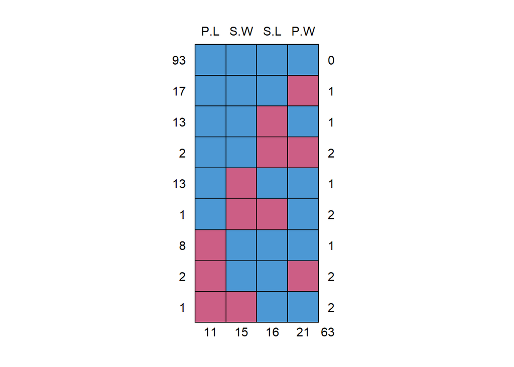

```
   P.L S.W S.L P.W
93   1   1   1   1  0
17   1   1   1   0  1
13   1   1   0   1  1
2    1   1   0   0  2
13   1   0   1   1  1
1    1   0   0   1  2
8    0   1   1   1  1
2    0   1   1   0  2
1    0   0   1   1  2
    11  15  16  21 63
```

```r
#install MICE
#install.packages("mice")
library(mice)

iris.mis2 <- iris.mis
colnames(iris.mis2) <- c("S.L", "S.W", "P.L", "P.W")
md.pattern(iris.mis2)
```

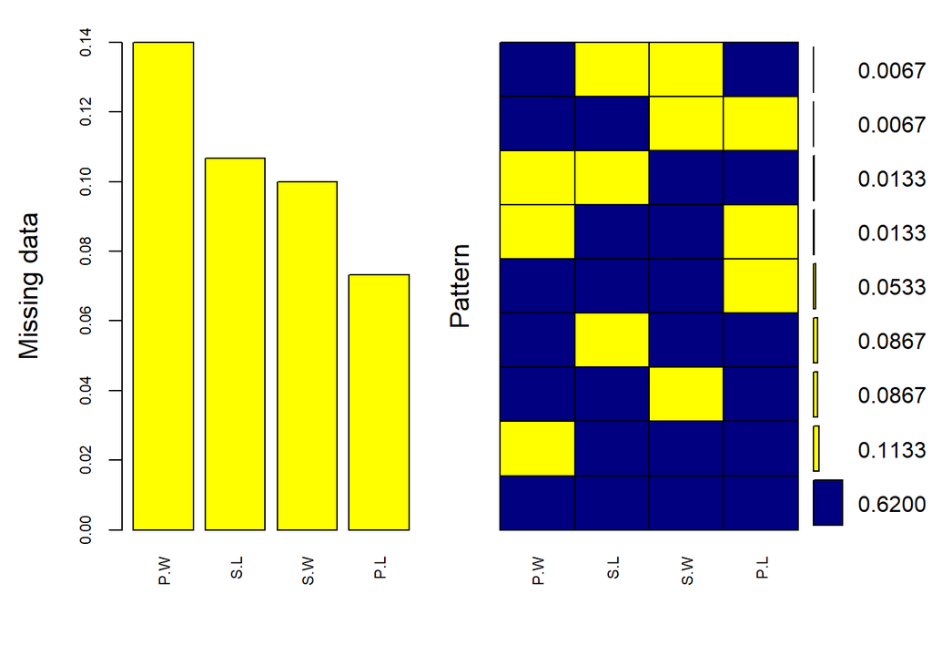

```
 Variables sorted by number of missings:
 Variable      Count
      P.W 0.14000000
      S.L 0.10666667
      S.W 0.10000000
      P.L 0.07333333
```

```r
# Wykres brakujących danych
#install.packages("VIM")
library(VIM)
mice_plot <- aggr(iris.mis, col=c('navyblue','yellow'),
                    numbers=TRUE, sortVars=TRUE,
                    labels=c("S.L", "S.W", "P.L", "P.W"), cex.axis=.7,
                    gap=3, ylab=c("Missing data","Pattern"))
```

```r
imputed_Data <- mice(iris.mis, m=5, maxit = 50, method = 'pmm', seed = 500)
  #  m  – Refers to 5 imputed data sets
  #  maxit – Refers to no. of iterations taken to impute missing values
  #  method – Refers to method used in imputation. we used predictive mean matching.
```

```r
summary(imputed_Data)
```

```
Class: mids
Number of multiple imputations:  5
Imputation methods:
Sepal.Length  Sepal.Width Petal.Length  Petal.Width
       "pmm"        "pmm"        "pmm"        "pmm"
PredictorMatrix:
             Sepal.Length Sepal.Width Petal.Length Petal.Width
Sepal.Length            0           1            1           1
Sepal.Width             1           0            1           1
Petal.Length            1           1            0           1
Petal.Width             1           1            1           0
```

```r
#check imputed values
head(imputed_Data$imp$Sepal.Width)
```

|  | 1 | 2 | 3 | 4 | 5 |
| --- | --- | --- | --- | --- | --- |
| 3 | 3.1 | 3.7 | 3.0 | 3.1 | 3.8 |
| 7 | 3.1 | 3.2 | 3.1 | 3.2 | 3.2 |
| 13 | 3.1 | 3.2 | 3.1 | 3.2 | 3.4 |
| 31 | 3.1 | 3.8 | 3.0 | 3.2 | 3.0 |
| 40 | 4.1 | 3.4 | 3.0 | 3.4 | 3.4 |
| 61 | 3.0 | 3.2 | 2.8 | 2.8 | 2.8 |

```r
#get complete data ( 2nd out of 5)
completeData <- complete(imputed_Data,2)

#build predictive model
fit <- with(data = iris.mis, exp = lm(Sepal.Width ~ Sepal.Length + Petal.Width))
```

#### AMELIA

`AMELIA` korzysta z algorytmu bazującego na wielowymiarowym rozkładzie normalnym do generowania brakujących danych. Dane muszą mieć rozklad normalny lub być przekształcone do rozkładu zbliżonego do normalnego. W porównaniu do `MICE` algorytm MVN (*ang. multivariate normal distribution*) jest gorszy w kilku aspektach: MICE wprowadza dane zmianna po zmiennej, podczas gdy MVN używa jednego wspólnego algorytmu opartego na wielowymiarowym rozkładzie normalnym (uogólnieniu rozkładu normalnego na n wymiarów) MICE potrafi radzić sobie z wieloma typami zmiennych, podczas gdy MVN wymaga danych o rozkładzie normalnym, bądź transformowanych do wartości przyblizonych do rozkładu normalnego. `MICE` jest w stanie generować dane na podstawie wybranych z całości danych, podczaas gdy `AMELIA` korzysta jedynie z całości uzupełnianych danych.

```r
#install package and load library
#install.packages("Amelia")
library(Amelia)

#load data
data("iris")

#seed 10% missing values
iris.mis <- prodNA(iris, noNA = 0.1)
summary(iris.mis)
```

```
  Sepal.Length    Sepal.Width     Petal.Length   Petal.Width
 Min.   :4.300   Min.   :2.000   Min.   :1.00   Min.   :0.100
 1st Qu.:5.100   1st Qu.:2.800   1st Qu.:1.50   1st Qu.:0.300
 Median :5.800   Median :3.000   Median :4.40   Median :1.300
 Mean   :5.863   Mean   :3.061   Mean   :3.73   Mean   :1.177
 3rd Qu.:6.425   3rd Qu.:3.300   3rd Qu.:5.10   3rd Qu.:1.800
 Max.   :7.900   Max.   :4.400   Max.   :6.90   Max.   :2.500
 NA's   :18      NA's   :8       NA's   :18     NA's   :13
       Species
 setosa    :44
 versicolor:44
 virginica :44
 NA's      :18
```

```r
#specify columns and run amelia
amelia_fit <- amelia(iris.mis, m=5, parallel = "multicore", noms = "Species")
```

```
-- Imputation 1 --

  1  2  3  4  5

-- Imputation 2 --

  1  2  3  4  5  6  7

-- Imputation 3 --

  1  2  3  4  5  6  7  8

-- Imputation 4 --

  1  2  3  4  5  6  7  8  9

-- Imputation 5 --

  1  2  3  4  5  6
```

```r
#access imputed outputs
amelia_fit$imputations[[1]]
```

| Sepal.Length | Sepal.Width | Petal.Length | Petal.Width | Species |
| --- | --- | --- | --- | --- |
| 5.100000 | 3.500000 | 1.400000 | 0.2000000 | setosa |
| 4.900000 | 3.000000 | 1.400000 | 0.2000000 | setosa |
| 4.700000 | 3.200000 | 1.300000 | 0.2000000 | setosa |
| 4.600000 | 3.100000 | 1.500000 | 0.2000000 | setosa |
| 5.481314 | 3.600000 | 1.400000 | 0.2000000 | setosa |
| 5.400000 | 3.900000 | 1.526705 | 0.4000000 | setosa |
| 4.600000 | 3.400000 | 1.400000 | 0.3000000 | setosa |
| 5.000000 | 3.400000 | 1.500000 | 0.2000000 | setosa |
| 4.400000 | 2.900000 | 1.400000 | 0.2000000 | setosa |
| 4.900000 | 3.100000 | 1.500000 | 0.1000000 | setosa |

[output cut: 140 more lines]

```r
amelia_fit$imputations[[5]]$Sepal.Length
```

```
  [1] 5.100000 4.900000 4.700000 4.600000 5.119376 5.400000 4.600000
  [8] 5.000000 4.400000 4.900000 5.400000 4.800000 5.383911 4.300000
 [15] 5.800000 5.700000 5.400000 5.100000 5.700000 5.100000 5.400000
 [22] 5.100000 4.600000 5.100000 5.217428 5.000000 5.000000 5.200000
 [29] 5.200000 4.700000 4.800000 5.400000 5.200000 4.777104 4.906545
 [36] 5.000000 5.500000 4.900000 4.400000 5.100000 5.000000 4.500000
 [43] 4.400000 5.000000 5.100000 4.800000 5.100000 4.600000 5.300000
 [50] 5.000000 7.000000 6.400000 6.900000 5.500000 6.500000 5.700000
 [57] 6.300000 5.227666 6.600000 5.200000 5.169441 5.900000 6.000000
 [64] 6.100000 5.600000 6.700000 5.600000 5.800000 5.453942 5.600000
 [71] 5.900000 6.100000 6.300000 6.100000 6.400000 6.600000 6.800000
 [78] 6.096870 6.000000 5.700000 5.500000 5.500000 5.800000 6.670164
 [85] 5.400000 6.000000 6.700000 6.300000 5.600000 5.500000 5.500000
 [92] 6.529073 6.141300 5.000000 5.600000 5.700000 5.700000 6.200000
 [99] 5.100000 5.700000 6.300000 6.112682 7.100000 6.436118 6.500000
[106] 7.600000 4.900000 7.300000 6.700000 7.200000 6.500000 6.400000
[113] 6.800000 5.999288 6.674207 6.400000 6.500000 7.700000 7.700000
[120] 6.000000 6.900000 5.600000 7.700000 6.300000 6.700000 7.200000
[127] 6.200000 6.100000 6.400000 7.200000 6.597388 7.900000 6.400000
[134] 6.300000 6.100000 7.700000 6.300000 6.400000 6.000000 6.900000
[141] 6.700000 6.900000 5.800000 6.800000 6.700000 6.700000 6.300000
[148] 6.500000 6.200000 6.519232
```

```r
#export the outputs to csv files
write.amelia(amelia_fit, file.stem = "imputed_data_set")
```

#### mi

`mi` (Multiple imputation with diagnostics) pozwala na dosotosowanie sposobu generowania danych zastępujących dane brakujące. Podobnie jak inne pakiety buduje wiele modeli w celu przybliżenia wprowadzanych wartości do najbardziej prawdopodobnych. Korzysta z metody przewidywania pasującej średniej (*ang. predictive mean matching method*).